# Prueba 2

> Alumno: Miguel Ángel Fernández Gutiérrez <mianfg@correo.ugr.es>

## Ejercicio 1

Vemos que ya tenemos el *dataset* `airquality` cargado en R:

```r
airquality
```

| Ozone | Solar.R | Wind | Temp | Month | Day |
| --- | --- | --- | --- | --- | --- |
| 41 | 190 | 7.4 | 67 | 5 | 1 |
| 36 | 118 | 8.0 | 72 | 5 | 2 |
| 12 | 149 | 12.6 | 74 | 5 | 3 |
| 18 | 313 | 11.5 | 62 | 5 | 4 |
| NA | NA | 14.3 | 56 | 5 | 5 |
| 28 | NA | 14.9 | 66 | 5 | 6 |
| 23 | 299 | 8.6 | 65 | 5 | 7 |
| 19 | 99 | 13.8 | 59 | 5 | 8 |
| 8 | 19 | 20.1 | 61 | 5 | 9 |
| NA | 194 | 8.6 | 69 | 5 | 10 |

[output cut: 143 more lines]

### Apartado 1

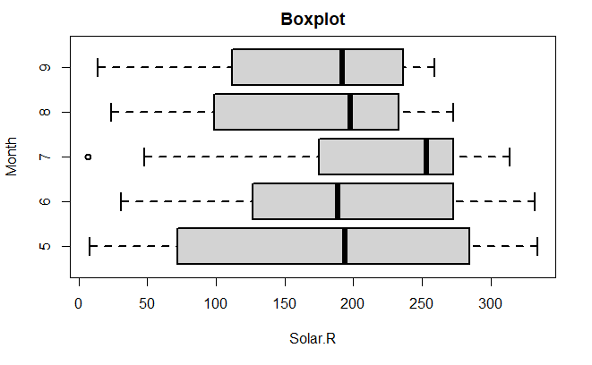

```r
boxplot(airquality$Solar.R~airquality$Month, horizontal=TRUE, lwd=2, main="Boxplot", xlab="Solar.R", ylab="Month")
```

### Apartado 2

Construimos tal diagrama de dispersión.

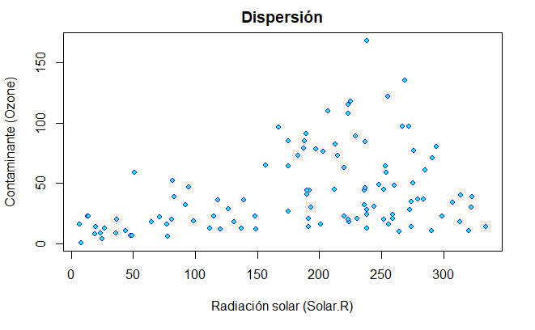

```r
plot(airquality$Solar.R, airquality$Ozone, main="Dispersión", xlab="Radiación solar (Solar.R)", ylab="Contaminante (Ozone)", pch=21, col='blue', bg='cyan', cex=0.9)
```

### Apartado 3

Creamos un modelo lineal que ajuste los datos.

```r
mod <- lm(airquality$Ozone~airquality$Solar.R)
mod
```

```
Call:
lm(formula = airquality$Ozone ~ airquality$Solar.R)

Coefficients:
       (Intercept)  airquality$Solar.R
           18.5987              0.1272
```

Y mostramos la recta sobre la gráfica de dispersión anterior.

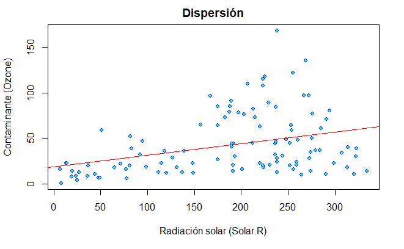

```r
plot(airquality$Solar.R, airquality$Ozone, main="Dispersión", xlab="Radiación solar (Solar.R)", ylab="Contaminante (Ozone)", pch=21, col='blue', bg='cyan', cex=0.9)
abline(mod, col='red')
```

## Ejercicio 2

Primero, creamos las funciones pertinentes. En concreto, será $F^{-1}=\texttt{F.inv}$.

```r
F.inv <- function(u, a, b) b/(1-u)^(1/a)
```

### Apartado 1

Para ello, sencillamente generamos $n$ valores de una distribución $\mathcal{U}(0,1)$ y le aplicamos $F^{-1}$.

```r
n <- 1000
set.seed(1)
u <- runif(n)
x <- F.inv(u, a=5, b=4)
```

```r
x[1:10]
```

```
 [1] 4.254638 4.390209 4.741815 6.449096 4.184319 6.319350 7.136350 4.965560 4.877664 4.051349
```

### Apartado 2

Vamos a evaluar si esto es correcto.

> Para usar las funciones `dPareto` y `pPareto`, deberemos instalar la librería `Pareto` y luego ejecutar `library("Pareto")`. En la [referencia](https://cran.r-project.org/web/packages/Pareto/Pareto.pdf) podemos ver que $a$ corresponde con `alpha` y $b$ corresponde con `t`.

Primero lo hacemos con una gráfica que superponga un histograma de los valores obtenidos con la densidad suavizada y la densidad de la Pareto.

```r
hist(x,freq=FALSE,breaks='FD',main='Método de inversión (Pareto)')
lines(density(x), col='blue')
```

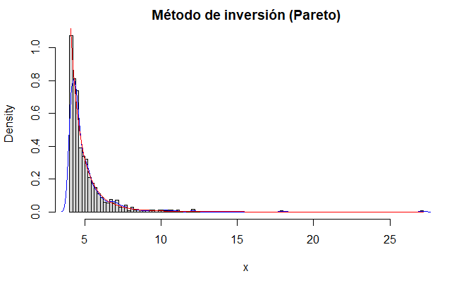

```r
curve(dPareto(x, alpha=5, t=4), add=TRUE, col='red')
```

Finalmente, realizamos el test de Kolmogorov-Smirnov.

```r
ks.test(x, pPareto, alpha=5, t=4)
```

```
    Asymptotic one-sample Kolmogorov-Smirnov test

data:  x
D = 0.024366, p-value = 0.5928
alternative hypothesis: two-sided
```

Sólo podríamos rechazar la hipótesis nula (la muestra es de la distribución) si tuviésemos un $\alpha>0.5928$. Esto nos indica que no se observan desviaciones de tal hipótesis nula, y que por tanto las observaciones corresponden a la distribución Pareto de $a=5$, $b=4$. Por tanto, nuestro método de generación es adecuado.